# Math 421 - Midterm

## II. Data Visualization

Continue with the data from part I.

1. Provides at least 10 meaningful plots. Comments on the plots. All plots should have title, caption, appropriate labels on x and y-axis

```r
#PLOT1
library(tidyverse)
df1 <- df %>%
  mutate(sex = as.factor(sex))
g1 = df1 %>% ggplot()+
  geom_smooth(mapping = aes(x=age, y=los, color=sex))+
  labs(x='Age',
       y='Length of Stay Composition by Age',
       caption = 'The data shows that for both sexes, the length of stay peaks at around age 13. Males being 11 days and females being 8.')

ggsave(filename = 'plot1.png', plot = g1)
```

```r
#PLOT2
df1 <- df %>%
  mutate(sex = as.factor(sex))
g2 = df1%>% filter(age<=19, age>= 10) %>%
  ggplot()+
  geom_point(mapping = aes(x=tot, y=age, color = sex))+
  labs(x='Total Charge',
       y='Age',
       title = 'Total Charge Distribution by Teenagers',
       caption = 'The data shows that within the teenage age range of 10-19, the highest charge was a male 14 year old with a charge around 2400000.')
ggsave(filename = 'plot2.png', plot = g2)
```

```r
#PLOT3
g3 = df %>% filter(sex =='1' | sex =='2') %>%
  ggplot()+
  geom_boxplot(mapping = aes(x=sex, y=age))+
  labs(x='Sex',
       y='Age',
       title = 'Age vs Sex',
       caption = 'The data shows that the median age within the female and male gender is around 57.' )
ggsave(filename = 'plot3.png', plot = g3)
```

```r
#PLOT4
library(knitr)
library(lubridate)

df1 <- df %>%
  mutate(provider = as.factor(provider))

g4 = df1 %>% filter(age < 50, age >45) %>%
  ggplot()+
  geom_bar(mapping = aes(x=age, fill=provider), position = 'fill')+
  labs(x='Age',
       y='Proportion of Provider',
       title= 'Provider Distribution from Ages 45-50',
       caption = 'The data shows that within the age range of 45-50, the most popular provider is Rhode Island Hospital.')
ggsave(filename = 'plot4.png', plot = g4)
```

```r
#PLOT5
df1 <- df %>%
  mutate(sex = as.factor(sex))

g5 = df1 %>% filter(tot<50000) %>%
group_by(los, sex) %>%
  summarise(meantot = mean(tot)) %>%
ggplot()+
  geom_col(mapping = aes(x=los, y=meantot, fill=sex), position = 'dodge')+
  labs(x='Length of Stay',
       y='Total Charge',
       title= 'Total Charges VS Length of Stay by Sex',
       caption = 'The data shows that the longer the stay, the higer the charge.')

ggsave(filename = 'plot5.png', plot = g5)
```

```r
#PLOT6
df1 <- df %>%
  mutate(sex = as.factor(sex))
g6 = df1 %>%
  ggplot()+
  geom_bar(mapping = aes(x=moa, fill=sex), position = 'dodge')+
  labs(x='Month of Admission',
       y='Count of Individuals',
       title = 'Month of Admission by Sex',
       caption = 'The data shows that for males, the month with the most admissions was October. For females, the month with the most admissions was January.')

ggsave(filename = 'plot6.png', plot = g6)
```

```r
#PLOT7
df1 <- df %>%
  mutate(sex = as.factor(sex))
g7 = df1 %>%
  ggplot()+
  geom_col(mapping = aes(x=sex, y= los, fill = season), position = 'dodge')+
  labs(x='Sex',
       y='Length of Stay',
       title = 'Length of Stay vs Sex by Seasons',
       caption = 'The data shows that for males, the longest length of stays were in the summer, and for femailes in the fall.')

ggsave(filename = 'plot7.png', plot = g7)
```

```r
#PLOT8
df1 <- df %>%
  mutate(sex = as.factor(sex))
g8 = df1 %>%
  ggplot()+
  geom_density(mapping = aes(x=age, colour = sex))+
  labs(x='Age',
       y='Density',
       title ='',
       caption = 'The data shows that within the dataset, there is a vast majority of males that are 65, and for females it peaks at 30 and again around 74.')

ggsave(filename = 'plot8.png', plot = g8)
```

```r
#PLOT9
g9 = df %>% filter(age>30, age<55, tot<50000, tot>40000) %>%
  ggplot()+
  geom_point(mapping = aes(x=age, y=tot))+
  facet_wrap(~provider)+
  labs(x='Age Range',
       y='Total Charge',
       title = 'Age and Total Charge Distribution by Provider',
       caption = 'The data shows that provider 7205, Rhode Island Hospital, has the most charges and provider 7211, Westerly, has the least.')

ggsave(filename = 'plot9.png', plot = g9)
```

```r
#PLOT10
df1 <- df %>%
  mutate(sex = as.factor(sex))
g10 = df1 %>%
  group_by(sex, provider) %>%
  summarise(mean_tot = mean(tot)) %>%
  ggplot()+
  geom_col(aes(x=provider, y=mean_tot, fill=sex), position = 'dodge')+
  labs(x='Provider',
       y='Average Total Charge',
       title = 'Mean Tota Charge by Provider and Sex',
       caption = 'The data shows that throughout the providers, males have a higher total charge.')

ggsave(filename = 'plot10.png', plot = g10)
```

2. Make an animation plot.

```r
library(lubridate)
library(gganimate)
library(tidyverse)
library(dplyr)
library(ggplot2)
library(knitr)

df1 = df

df1$month <- month(df1$moa)
d1 <- df1 %>% group_by(month, provider) %>% summarise(mean= mean(tot))
d2 <- d1 %>% group_by(month) %>% mutate(rank= rank(-mean))
d3 <- d2 %>% filter(rank <= 5)

aa = a1 <- d3 %>% ggplot(aes(x=rank, y=mean, group=provider, fill=provider, label=provider))+ geom_col()+
  geom_text(aes(y=mean, label=provider), hjust = 1.4)+
  coord_flip(clip = 'off', expand = FALSE)+scale_x_reverse()+
  labs(title = 'Month {closest_state}', x='', y='Total Charge', fill='Provider')+
  theme(plot.title = element_text(hjust = 1, size = 22), axis.ticks.y = element_blank(), axis.text.y = element_blank())+
  transition_states(month)+
  ease_aes('cubic-in-out')

anim = animate(a1, nframes=400)

anim_save("animation.gif", animation = anim)
```

3. Write a paragraph to summarize the section and give your comments on the results.

```r
#After going through the data and looking at it from a different perspective helped see how large and challenging this dataset is. There are many variables that coincide and after creating plots on the data, it helped show which provider was the most popular and expensive, and that was Rhode Island Hospital. There was also a lot to see with coorelation of length of stay, sex, and age.
```

## III. Predictive Models

Continue with the data from part I. Make sure you do not have any missing values in the data. Use the follows as the target and input variables:

*Target Variable*: Create the target variable taking value of

- `low` if the total charge of a patient (`tot`) is smaller than the median of the total charge, and
- `high` otherwise.

```r
median(df$tot)
```

```
## [1] 21854
```

```r
df$target <- ifelse(df$tot<21854,'low','high')

df <- df %>%
  mutate(target=as.factor(target))
```

*Input Variables*:

- “age”,“sex”,“raceethn”,“provider”,“moa”,“mod”,“admtype”,“campus”, ‘los’

```r
df1 = df

df1 = df1 %>% select("age", "sex", "provider", "moa", "mod", "campus", "los", "target")
```

1. Use `filter` function to filter out rows where `raceethn==''` or `admtype==''`. Make sure all the categorical variables are factor, numeric variables are numeric. Set Training : Testing Split = 10 : 90

```r
# df1 = df1 %>%  filter(!raceethn=='', !admtype=='')

library(caret)

splitIndex <- createDataPartition(df1$target, p=0.10, list = FALSE)

df_train <- df1[splitIndex,]
df_test <- df1[-splitIndex,]
```

2. Train a decision tree using `rpart`. Plot the decision tree. Plot the variable importance ranked by the tree.

```r
library(rpart)

model1 <- train(target~., data = df_train,
                method = "rpart2",
                maxdepth=3)

pred <- predict(model1, df_test)
cm <- confusionMatrix(data = pred, reference = df_test$target)

cm$overall[1]
```

```
## Accuracy
## 0.766845
```

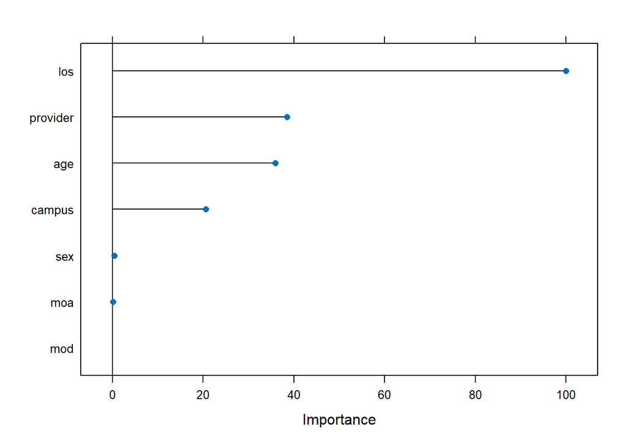

```r
plot(varImp(model1))
```

3. Using caret for this question. Set `Training Control` to be: Use Cross-Validation of 5 folds across all models. Train & tune at least 2 different models (i.e. two different values for `method=` in the train function of caret). Plot the hyper-parameter tuning plots for each model.

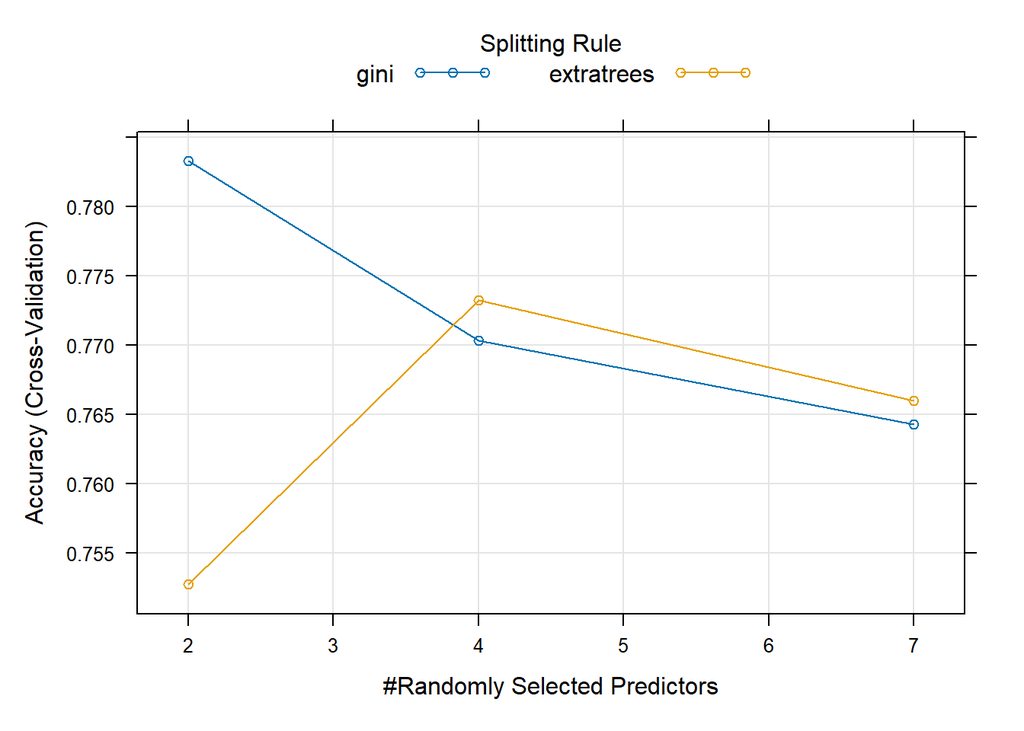

```r
library(caret)

trControl = trainControl(method = "cv",
                         number = 5)

forest_ranger <- train(target~., data = df_train,
                       method = "ranger",
                       trControl = trControl)

plot(forest_ranger)
```

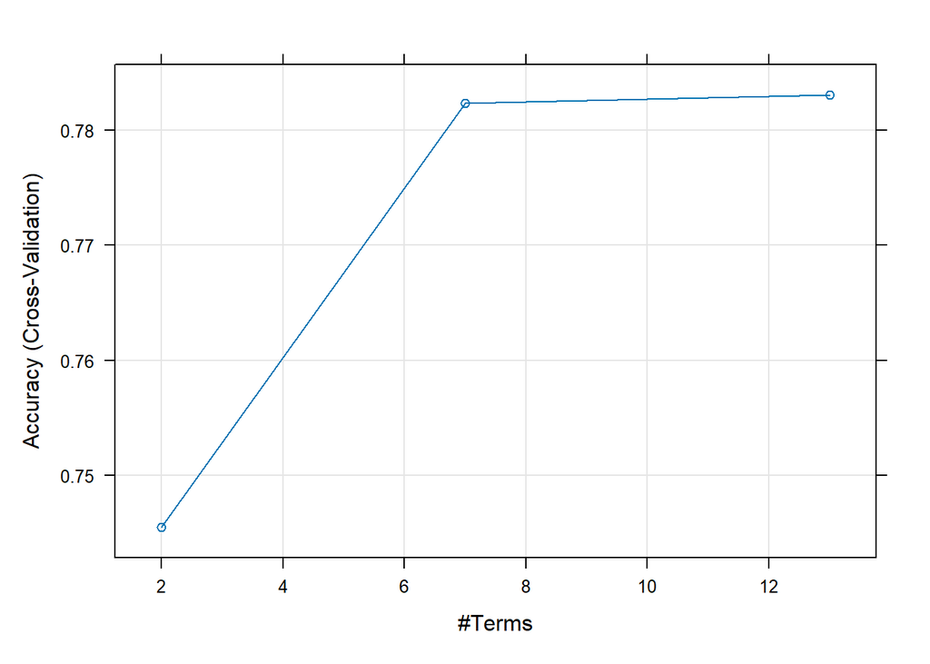

```r
trControl = trainControl(method = "cv",
                         number = 5)

fda <- train(target~., data = df_train,
                        method = "fda",
                        trControl = trControl)

plot(fda)
```

4. Plot the comparison of the models in 3.

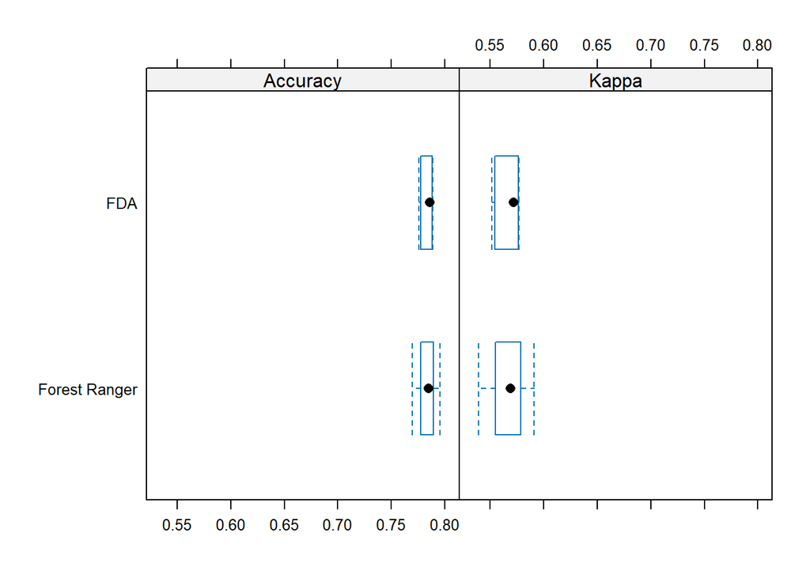

```r
results <- resamples(list('Forest Ranger' = forest_ranger,
                          'FDA' = fda))
bwplot(results)
```

5. What is your final selection for the model? Test the accuracy of your final model on the test data.

```r
pred <- predict(forest_ranger, df_test)
cm <- confusionMatrix(data = pred, reference = df_test$target)

cm$overall[1]
```

```
##  Accuracy
## 0.7907022
```

6. Create another `target` variable (binary), decide the input variables and redo 1 to 5.

```r
median(df$age)
```

```
## [1] 56
```

```r
#Creating the new Target
df2 = df

df2$target <- ifelse(df2$age<56,'low','high')

df2 <- df2 %>%
  mutate(target=as.factor(target))

#Selecting the Variables

df2 = df2 %>% select("age", "sex", "provider", "moa", "mod", "campus", "los", "target")
```

```r
#1
library(caret)

splitIndex <- createDataPartition(df2$target, p=0.10, list = FALSE)

df_train <- df2[splitIndex,]
df_test <- df2[-splitIndex,]
```

```r
#2
library(rpart)

model1 <- train(target~., data = df_train,
                method = "rpart2",
                maxdepth=3)
```

```
## note: only 1 possible values of the max tree depth from the initial fit.
##  Truncating the grid to 1 .
```

```r
pred <- predict(model1, df_test)
cm <- confusionMatrix(data = pred, reference = df_test$target)

cm$overall[1]
```

```
## Accuracy
##        1
```

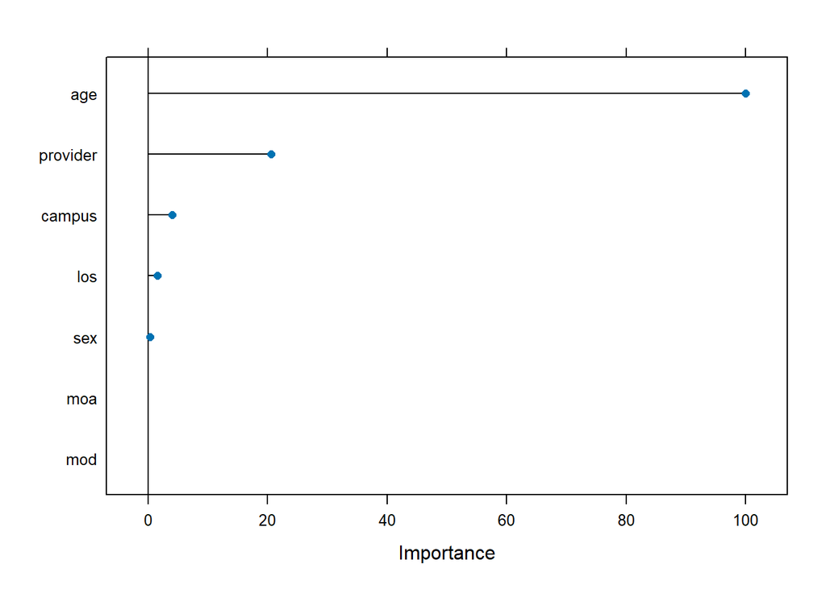

```r
plot(varImp(model1))
```

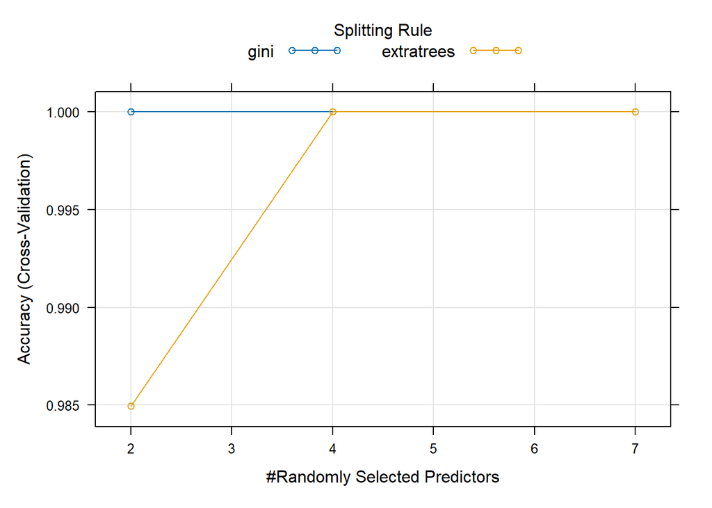

```r
#3a
library(caret)

trControl = trainControl(method = "cv",
                         number = 5)

forest_ranger <- train(target~., data = df_train,
                       method = "ranger",
                       trControl = trControl)

plot(forest_ranger)
```

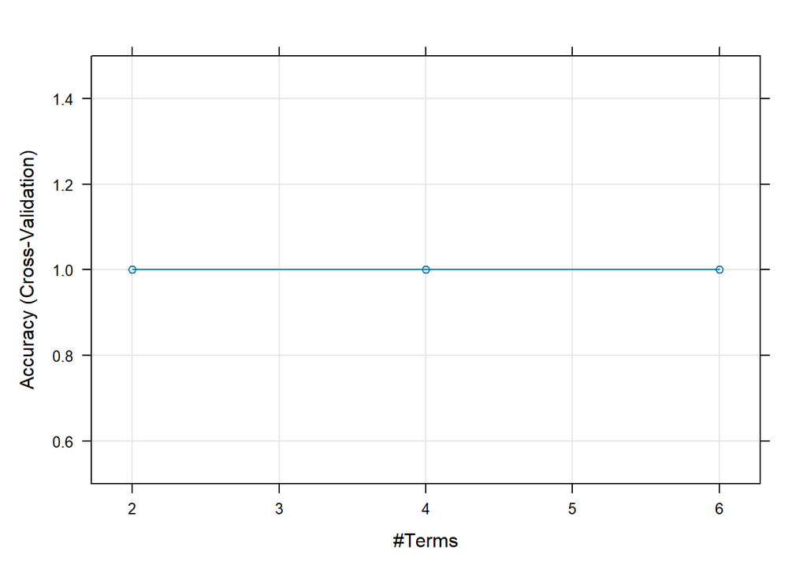

```r
#3b
trControl = trainControl(method = "cv",
                         number = 5)

fda <- train(target~., data = df_train,
                        method = "fda",
                        trControl = trControl)

plot(fda)
```

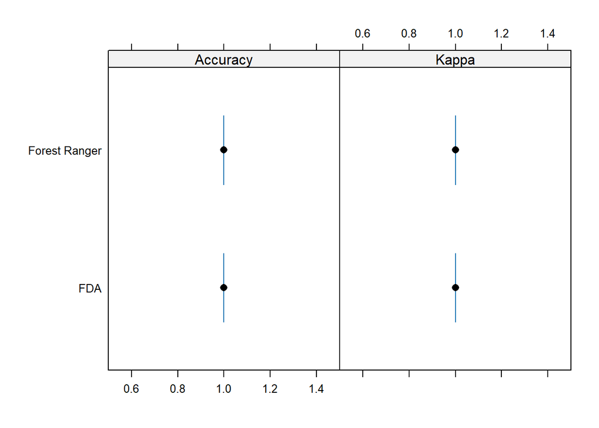

```r
#4
results <- resamples(list('Forest Ranger' = forest_ranger,
                          'FDA' = fda))

bwplot(results)
```

```r
#5
pred <- predict(forest_ranger, df_test)
cm <- confusionMatrix(data = pred, reference = df_test$target)

cm$overall[1]
```

```
## Accuracy
##        1
```

7. Write a paragraph to summarize the section and give your comments on the results.

```r
#After going through the data and creating decision trees, the data shows that when the total charge was the target variable that it is 79% accurate. However when going through and changing the target to age, the data showed that it is 100% accurate. This can be due to a perfect model or overfitting.
```